# Homework 1

Almog S. and Tomer M.

# Homework 1

### Instructions

1. All assignments are individual!
2. This assignment should be uploaded as one “html” file (after knit) before 23/3/2021, 23:59.
3. There are 6 questions in this assignment, if you want to pass it you must code all 6 of them.
4. Questions about the assignment should be asked using the Assignments forums.
5. Because this is and advanced course, questions about compilation and installment of R and libraries will not be answered! (Look it up in Google)
6. This you should copy the code from this assignment and create an .rmd file to work with.
7. All of the instructions of this assignment should be included in the final .html file.

The goal of this homework is to introduce you to R, RStudio and R Markdown. In the assignment you will need to submit the .rmd file created by this markdown project, where every chunk is filled properly based on the instructions.

First, lets set the knit options with parameter ‘echo=True’. This will allow the knit to create a html output file, where the code written by you will be presented before it’s output. In addition, we will load the library tidyverse. (If not installed, follow the instructions here: https://www.tidyverse.org/help/ )

```r
knitr::opts_chunk$set(echo = TRUE)
library(tidyverse)
```

## Including Plots

First, lets plot without using tidyverse:

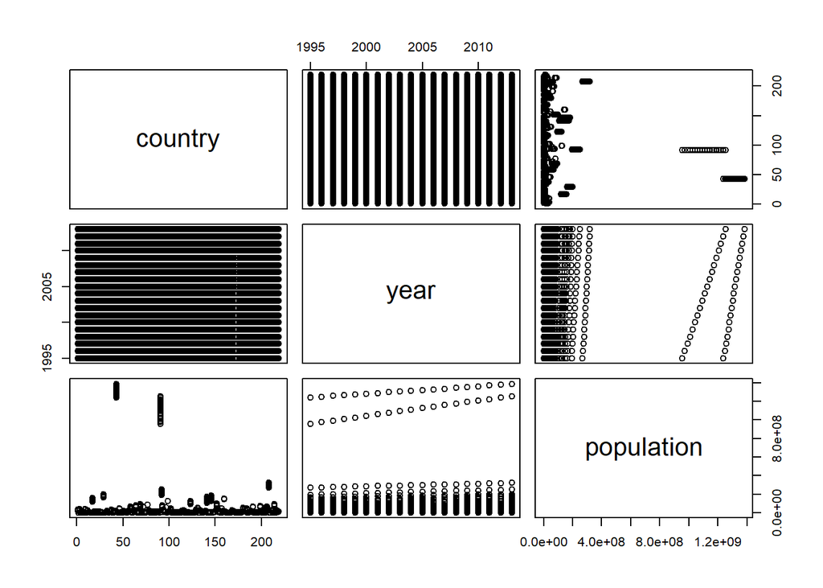

```r
plot(population)
```

This shows relations between each pair of columns in the ‘population’ table’, however, without filtering and focusing on specific data, we are not able to detect any patterns.

### ‘Population’ table

Let’s start by checking what are the columns of the table:

```r
glimpse(population)
```

```
## Rows: 4,060
## Columns: 3
## $ country    <chr> "Afghanistan", "Afghanistan", "Afghanistan", "Afghanista...
## $ year       <int> 1995, 1996, 1997, 1998, 1999, 2000, 2001, 2002, 2003, 20...
## $ population <int> 17586073, 18415307, 19021226, 19496836, 19987071, 205953...
```

Q1. Change the function so we can get a subset of the data where the only country is Israel

```r
population %>%
  filter(country=="Israel")
```

```
## # A tibble: 19 x 3
##    country  year population
##    <chr>   <int>      <int>
##  1 Israel   1995    5331622
##  2 Israel   1996    5486219
##  3 Israel   1997    5630066
##  4 Israel   1998    5764197
##  5 Israel   1999    5891263
##  6 Israel   2000    6013711
##  7 Israel   2001    6129590
##  8 Israel   2002    6238958
##  9 Israel   2003    6348782
## 10 Israel   2004    6468354
## 11 Israel   2005    6603677
## 12 Israel   2006    6758761
## 13 Israel   2007    6930068
## 14 Israel   2008    7106828
## 15 Israel   2009    7273804
## 16 Israel   2010    7420368
## 17 Israel   2011    7542327
## 18 Israel   2012    7643905
## 19 Israel   2013    7733144
```

Q2. In the following chunk, save the subset above as ‘pop_1’, so you can plot more information about the data

```r
pop_1 <- population %>%
  filter(country=="Israel")
```

Q3. In the following chunk, create a **line plot** where you can see the change in population in Israel between the years 1995 and 2013 (use pop_1)

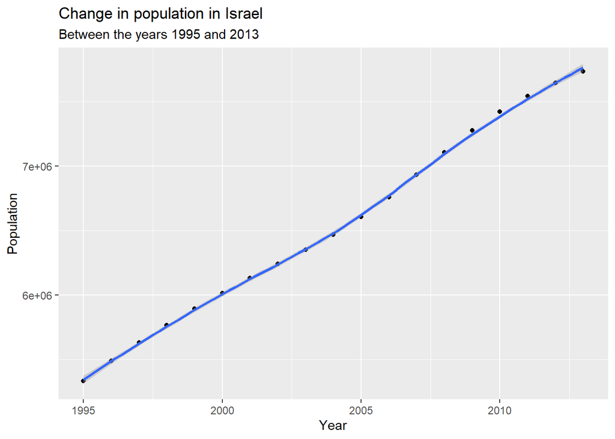

```r
ggplot(pop_1, mapping = aes(x = year, y = population)) +
  geom_point() +
  geom_smooth() +
  labs(title = "Change in population in Israel",subtitle ="Between the years 1995 and 2013", x = "Year", y = "Population")
```

Q4. In the following chunk, please filter the years 2004-2013 to see the change in population in 10 years:

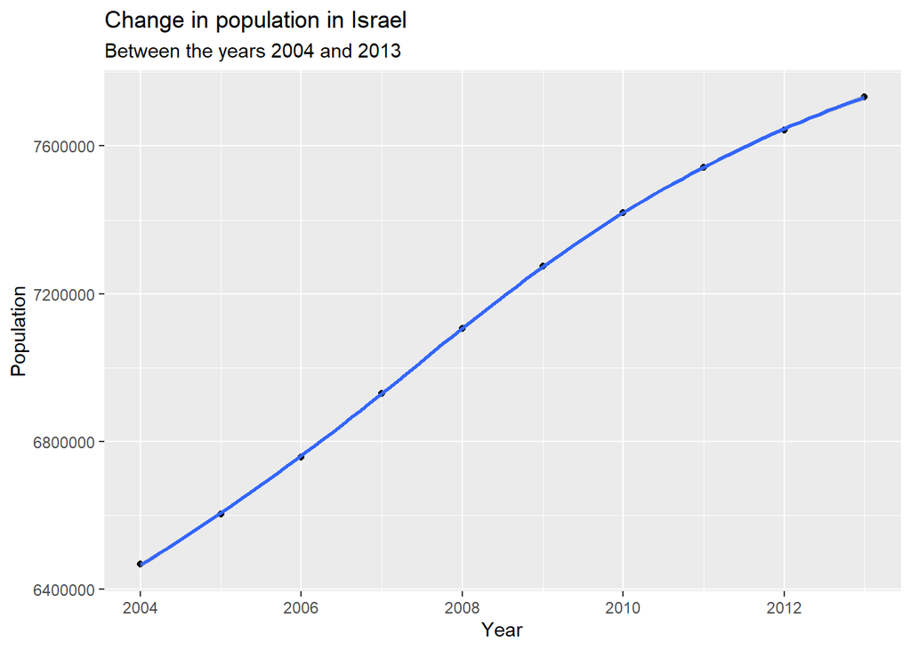

```r
pop1_04_13 <- pop_1 %>%
  filter(between(year,2004,2013))
ggplot(pop1_04_13, mapping = aes(x = year, y = population)) +
  geom_point() +
  geom_smooth() +
  labs(title = "Change in population in Israel",subtitle ="Between the years 2004 and 2013", x = "Year", y = "Population")
```

## Seatbelts dataset

Let’s take a look at another dataset, called “Seatbelts”, which is based on the “Road Casualties in Great Britain 1969-84” inbuilt R data set. The ‘Seatbelts’ data set in R is a multiple time-series data set that was commissioned by the Department of Transport in 1984 to measure differences in deaths before and after front seatbelt legislation was introduced on 31st January 1983.

For simpler view, run the following chunk:

```r
data(Seatbelts)
Seatbelts <- data.frame(Year=floor(time(Seatbelts)),
Month=factor(cycle(Seatbelts),
labels=month.abb), Seatbelts)
```

```r
head(Seatbelts)
```

```
##   Year Month DriversKilled drivers front rear   kms PetrolPrice VanKilled law
## 1 1969   Jan           107    1687   867  269  9059   0.1029718        12   0
## 2 1969   Feb            97    1508   825  265  7685   0.1023630         6   0
## 3 1969   Mar           102    1507   806  319  9963   0.1020625        12   0
## 4 1969   Apr            87    1385   814  407 10955   0.1008733         8   0
## 5 1969   May           119    1632   991  454 11823   0.1010197        10   0
## 6 1969   Jun           106    1511   945  427 12391   0.1005812        13   0
```

```r
str(Seatbelts)
```

```
## 'data.frame':    192 obs. of  10 variables:
##  $ Year         : Time-Series  from 1969 to 1985: 1969 1969 1969 1969 1969 ...
##  $ Month        : Factor w/ 12 levels "Jan","Feb","Mar",..: 1 2 3 4 5 6 7 8 9 10 ...
##  $ DriversKilled: num  107 97 102 87 119 106 110 106 107 134 ...
##  $ drivers      : num  1687 1508 1507 1385 1632 ...
##  $ front        : num  867 825 806 814 991 ...
##  $ rear         : num  269 265 319 407 454 427 522 536 405 437 ...
##  $ kms          : num  9059 7685 9963 10955 11823 ...
##  $ PetrolPrice  : num  0.103 0.102 0.102 0.101 0.101 ...
##  $ VanKilled    : num  12 6 12 8 10 13 11 6 10 16 ...
##  $ law          : num  0 0 0 0 0 0 0 0 0 0 ...
```

Q5. Make the plot the following aggregation using ggplot (Drivers killed per year), add labels and title to the plot.

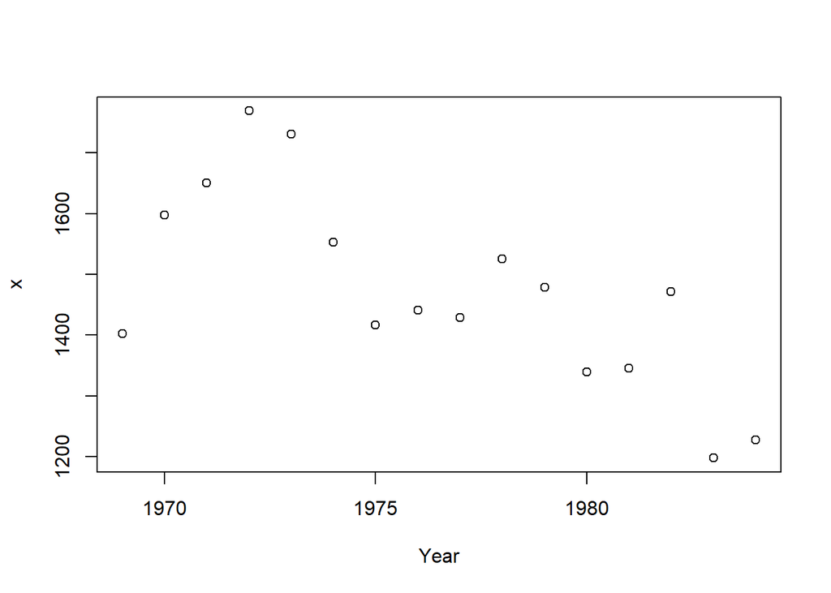

```r
plot(aggregate(Seatbelts$DriversKilled, by=list(Year=Seatbelts$Year), FUN=sum))
```

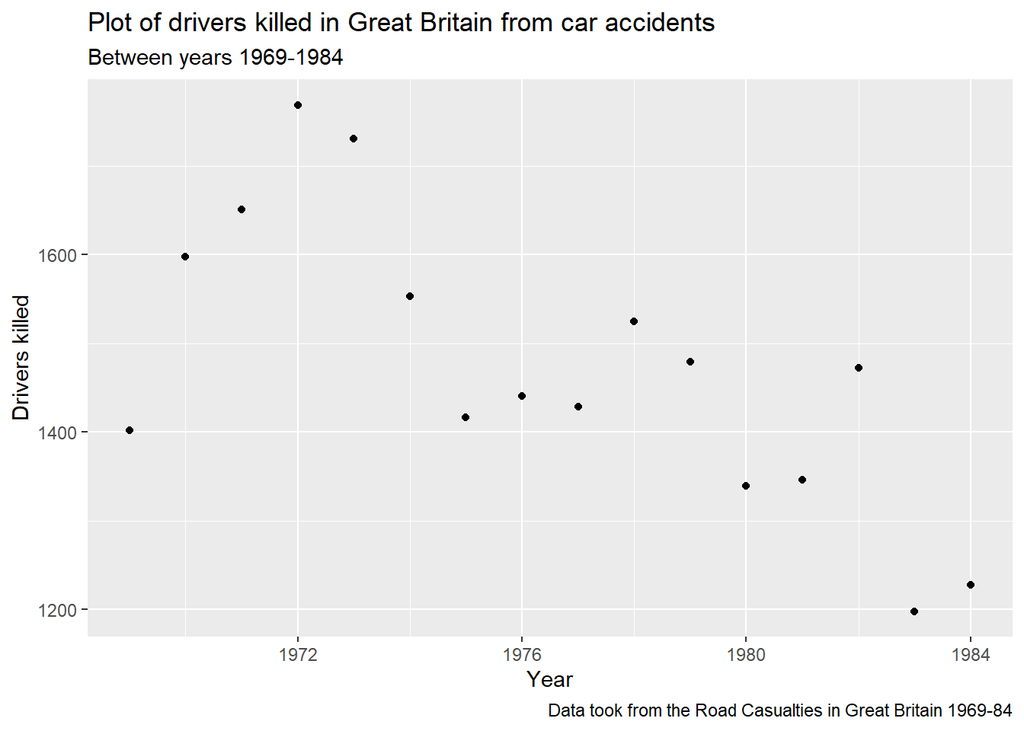

```r
ggplot(data = Seatbelts, mapping = aes(x = Year, y =DriversKilled )) +
  stat_summary(aes(y = DriversKilled),fun = "sum",, geom = "point") +
  labs(title = "Plot of drivers killed in Great Britain from car accidents",subtitle = "Between years 1969-1984",caption = "Data took from the Road Casualties in Great Britain 1969-84" ,x = "Year", y = "Drivers killed")
```

Q6. Make the plot proportionate to the number of drivers every year. Can you see the difference?

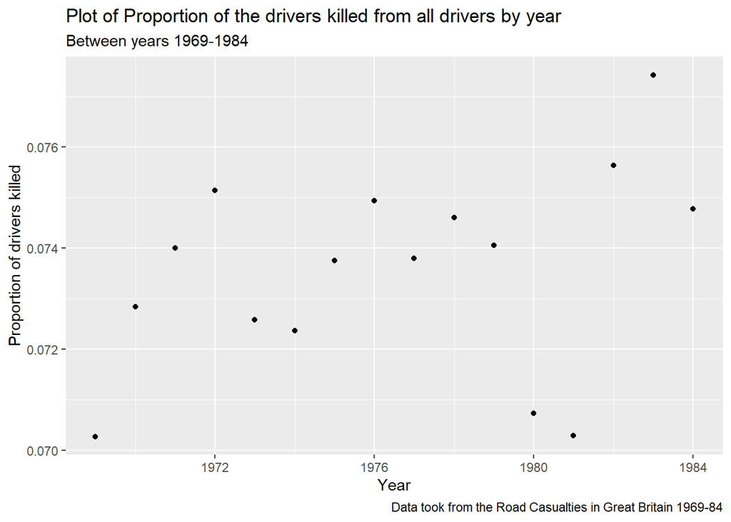

```r
grouped_by_year <- Seatbelts %>% group_by(Year)
grouped_by_year <-grouped_by_year %>% summarise(DriversKilled = sum(DriversKilled),drivers = sum(drivers))
ggplot(data = grouped_by_year, mapping = aes(x = Year, y =DriversKilled/drivers )) +
  geom_point() +
  labs(x = "Year", y = "Proportion of drivers killed", title = "Plot of Proportion of the drivers killed from all drivers by year",subtitle = "Between years 1969-1984",caption = "Data took from the Road Casualties in Great Britain 1969-84")
```